# 2. NLP 기술 빠르게 훑어보기

이 자에서는 전통적인 NLP 개념과 방법론을 둘러볼 것이다.

## 말뭉치, 토큰, 타입

모든 NLP 작업은 말뭉치(corpus)라 부르는 텍스트 데이터로 시작한다. 말뭉치는 일반적으로 원시 텍스트와 이 텍스트에 연관된 메타데이터를 포함한다.

원시 텍스트는 문자 시퀀스지만 일반적으로 문자를 **토큰이라는 연속된 단위로 묶었을 때 유용**하다. 영어에서 토큰은 **공백 문자나 구두점으로 구분되는 단어와 숫자에 해당**된다.

메타데이터는 식별자, 레이블, 타임스탬프 등 텍스트와 관련된 어떤 부가 정보도 될 수 있다. 머신러닝 분야에서는 메타데이터가 붙은 텍스트를 **샘플** 또는 **데이터 포인트**라고 한다. 샘플의 모음인 말뭉치는 **데이터셋**이라고 한다.

이 책은 머신러닝에 초점을 맞추므로 말뭉치와 데이터셋이란 용어를 혼용해서 사용하겠다.

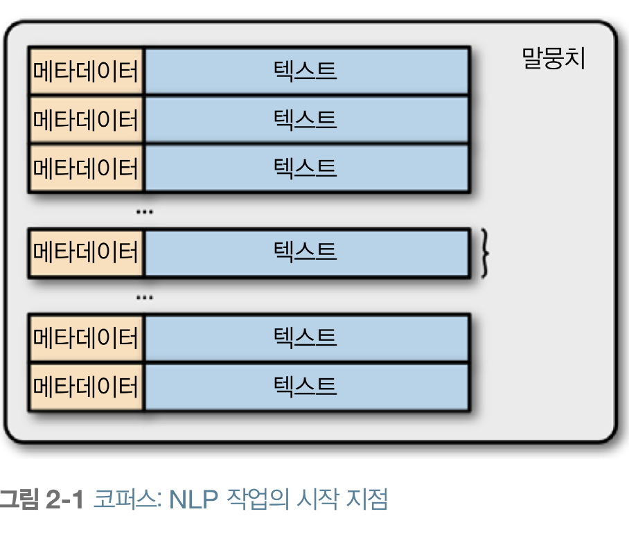

토큰화는 **텍스트를 토큰으로 나누는 과정**을 위미한다.

토큰화는 알파벳과 숫자가 아닌 문자를 기준으로 텍스트를 나누는 작업보다 더 복잡할 수 있다. 터키어와 같은 교착어는 공백 문자와 구두점으로 나누는 것으로 충분하지 않다.

앞으로 살펴 보겠지만, 텍스트를 바이트 스트림으로 신경망에 표현하여 토큰화 문제를 완전히 피해 갈 수 있다.

트윗을 예시로 보자. 트윗을 토큰화하려면 해시태그, @, :+)와 같은 스마일리, URL을 하나의 단위로 인식해야 한다. 그렇다면 '#MakeAMovieCold' 해시태그는 토큰이 하나일까? 아니면 4개일까?

연구 논문은 보통 이런 문제에 큰 관심이 없다. 토큰화의 기준은 저마다 다르다. 하지만 이런 결정은 실제 정확도에 생각보다 더 큰 영향을 미칠 수 있다. 오픈 소스 NLP 패키지는 대부분 기본적인 토큰화를 제공해 고된 전처리 작업을 덜어준다.

아래에서는 텍스트 처리 분야에 널리 사용되는 패키지인 NLTK, spaCy의 예를 볼 수 있다.

```python
import spacy
nlp = spacy.load('en_core_web_sm')
doc = nlp("he was running late")
for token in doc:
    print('{} --> {}'.format(token, token.lemma_))
```

예를 들어 spacy는 사전에 정의된 WordNet 사전을 사용해 표제어를 추출한다. 하지만 표제어 추출은 언어의 형태론을 이해하려는 머신러닝의 문제로 나타낼 수 있다.

어간 추출은 표제어 추출 대신에 사용하는 축소 기법이다. 수동으로 만든 규칙을 사용해 단어의 끝을 잘라 어간이라는 공통 형태로 축소한다. 오픈 소스 패키지에 구현된 Porter와 Snowball 어간 추출기가 유명하다.

## 문장과 문서 분류하기

문서를 분류하는 작업은 NLP 분야의 초기 애플리케이션 중 하나이다. 1장에서 소개한 TF와 TF-IDF 표현이 문서나 문장 같은 긴 텍스트 뭉치를 분류하는 데 유용하다.

토픽 레이블 할당, 리뷰의 감성 예측, 스팸 이메일 필터링, 언어 식별, 이메일 분류 같은 작업은 지도 학습 기반의 문서 분류 문제이다.

## 단어 분류하기 : 품사 태깅

문서에 레이블을 할당하는 개념을 단어나 토큰으로 확장할 수 있다.

단어 분류 작업의 예로는 **품사 태깅**이 있다.

```python
doc = nlp('Mary slapped the green witch.')
for token in doc:
    print('{} - {}'.format(token, token.pos_))
```

## 청크 나누기와 개체명 인식

종종 연속된 여러 토큰으로 구분되는 텍스트 구에 레이블을 할당해야 한다.

"Mary slapped the green witch." 문장을 예로 들어보자. 명사구와 동사구를 구별해야 한다고 할 때, 이를 **청크 나누기** 또는 **부분 구문 분석**이라고 한다.

부분 구문 분석의 목적은 **명사, 동사, 형용사 같은 문법 요소로 구성된 고차원의 단위를 유도**해 내는 것이다.

부분 구문 분석 모델 훈련에 사용할 데이터가 없다면 품사 태깅에 정규식(regular expression)을 적용해 부분 구문 분석을 근사할 수 있다. 다행히 영어 등 널리 사용하는 언어에는 이미 이런 데이터와 사전 훈련된 모델이 있다.

```python
doc = nlp('Mary slapped the green witch.')
for chunk in doc.noun_chunks:
    print('{} - {}'.format(chunk, chunk.label_))
```

또 다른 유용한 단위는 개체명이다. 개체명은 사람, 장소, 회사, 약 이름과 같은 실제 세상의 개념을 의미하는 문자명이다. 고유 명사의 형태로 생각하면 될 것이다.

## 문장 구조

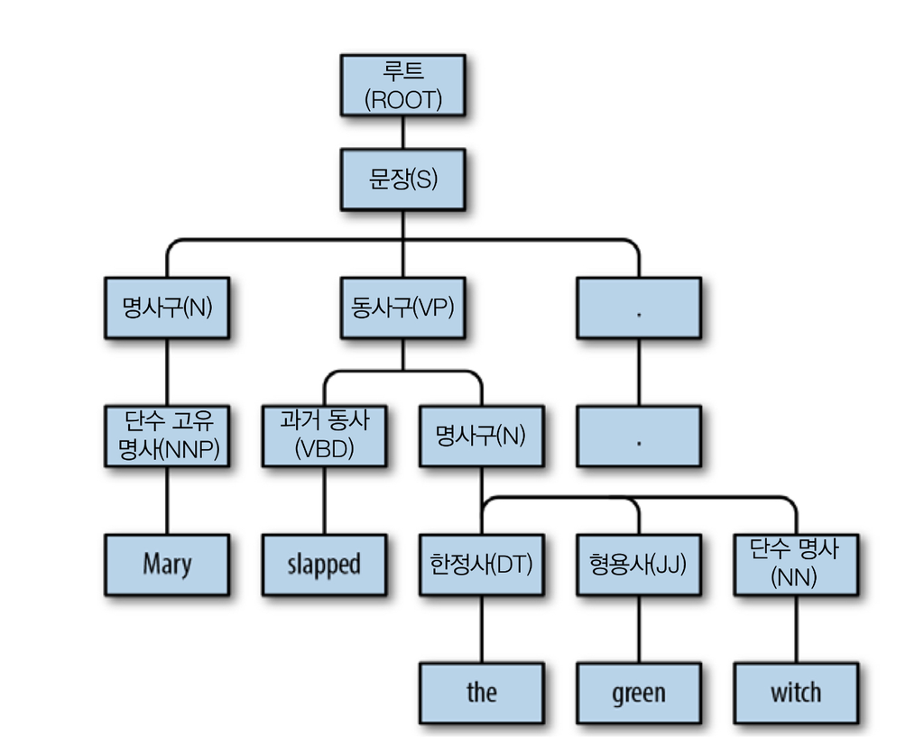

위와 같은 구분 분석 트리는 문장 안의 문법 요소가 계층적으로 어떻게 연관되는지 보여준다. 위와 같은 방식은 **구성 구문 분석**이라고 한다.

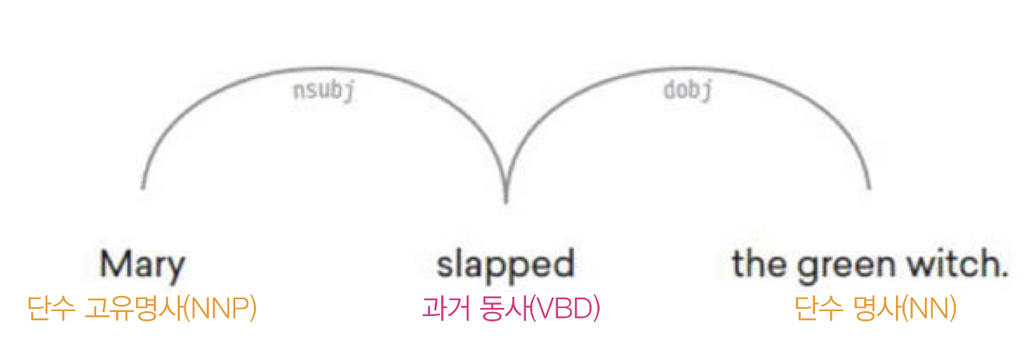

위와 같은 방법은 **의존 구문 분석**이라고 한다.

## 단어 의미와 의미론

단어에는 의미가 하나 이상 있다. 단어가 나타내는 각각의 뜻을 단어의 의미라고 한다.

WordNet은 모든 영어 단어의 관계와 의미를 수집하는 것이 목표이다. 이와 같은 방법은 현대적안 접근 방법에도 유용하다.

단어 으미ㅣ는 문맥으로 결정될 수도 있다. 텍스트에서 단어 의미를 자동으로 차즌ㄴ 일은 실제로 NLP에 적용된 첫 번째 준지도 학습이다.